# Identity Encoding Code 06:

Acoustic Space Figures

[Grace Smith-Vidaurre](http://smith-vidaurre.com/)<sup>1-4*</sup> <sup>1</sup>Department of Biology, New Mexico State University <sup>2</sup>Laboratory of Neurogenetics of Language, Rockefeller University <sup>3</sup>Field Research Center, Rockefeller University <sup>4</sup>Department of Biological Sciences, University of Cincinnati *gsvidaurre@gmail.com

12 June, 2023

This code accompanies the following paper in PLOS Computational Biology:

Smith-Vidaurre, G., Perez-Marrufo, V., Hobson, E.A., Salinas-Melgoza, A., and T.F. Wright. 2023. Individual identity information persists in learned calls of introduced parrot populations.

We visualized hierarchical mapping patterns by making plots of low-dimensional acoustic space across ranges, social scales, and similarity methods. For the site scale, we also made plots across the 3 datasets used to address potential repeated sampling of individuals: no filtering (full dataset), filtering by Gaussian mixture models, and filtering by visual classification. See the methods and appendix of the associated publication for more information about these analyses.

Check out Github repositories from previous work for related analyses and code:

- gsvidaurre/strong-individual-signatures<sup>[1]</sup>
- gsvidaurre/simpler-signatures-post-invasion<sup>[2]</sup>

Please cite both the associated papers and code (see DOIs on GitHub) if the code or analyses in these repositories are useful for your own research.

```r
rm(list = ls())

X <- c("tidyverse", "pbapply", "plyr", "dplyr", "data.table", "parallel", "scales", "ggplot2", "knitr", "utils", "egg", "gridExtra", "grid", "ggplotify")

invisible(lapply(X, library, character.only = TRUE))

# Suppress summarise warnings from dplyr
options(dplyr.summarise.inform = FALSE)

path <- "/media/gsvidaurre/MYIOPSITTA/R/VocalLearning_PostDisruption/Data"
gpath <- "/media/gsvidaurre/MYIOPSITTA/R/VocalLearning_PostDisruption/Graphics"
seed <- 401
cores <- parallel::detectCores() - 2
```

Read in the extended selection table (EST). Metadata and wave objects for pre-processed native and introduced range calls across the individual and site scales.

```r
nat_int_est <- readRDS(file.path(path, "monk_parakeet_contactCalls_rangeComparison_extSelTable.RDS"))
# glimpse(nat_int_est)
```

# Filtering out some calls

I dropped individual scale calls that had been added to the site scale (1 call per known repeatedly sampled individual in the final individual scale dataset, suffix “site_scale”).

```r
# 31 calls with the suffix "_site_scale". Not all of these belonged to the individuals in the final individual scale dataset, since some individuals that we repeatedly sampled were dropped due to low sample sizes after pre-processing
nat_int_est %>%
  dplyr::filter(social_scale == "Site") %>%
  dplyr::filter(grepl("_site_scale", sound.files)) %>%
  pull(sound.files) %>%
  length()
```

```
## [1] 31
```

```r
# Get the "_site_scale" calls for the final dataset of known repeatedly sampled individuals
indiv_ids <- nat_int_est %>%
  dplyr::filter(social_scale == "Individual") %>%
  pull(Bird_ID) %>%
  unique()

# 17 total: 8 native and 9 introduced range
indiv_ids
```

```
##  [1] "NAT-RAW"  "NAT-ZW8"  "NAT-UM2"  "NAT-UM3"  "NAT-UM4"  "NAT-UM1"
##  [7] "NAT-AAT"  "NAT-UM5"  "INT-UM1"  "INT-UM5"  "INT-UM6"  "INT-UM7"
## [13] "INT-UM9"  "INT-UM10" "INT-UM16" "INT-UM17" "INT-UM19"
```

```r
# INT-UM1, INT-UM6, and INT-UM19 were each the sole bird sampled at sites BART, ASCA, and CAME, respectively. These sites were not included at the site scale, so these individuals did not have any "_site_scale" calls
# This leaves 14 calls to drop, each representing a call for a different repeatedly sampled individual included in the site scale dataset
drop_is_calls <- nat_int_est %>%
  dplyr::filter(social_scale == "Site") %>%
  dplyr::filter(grepl("_site_scale", sound.files)) %>%
  dplyr::filter(Bird_ID %in% indiv_ids) %>%
  pull(sound.files)

length(drop_is_calls)
```

```
## [1] 14
```

```r
# Checking, looks good
# nat_int_est %>%
#   as_tibble() %>%
#   dplyr::filter(sound.files %in% drop_is_calls) %>%
#   dplyr::select(sound.files, Bird_ID) %>%
#   kable(align = rep("c", nrow(.)))

# Drop these calls from the extended selection table and continue with analyses
# nat_int_est <- nat_int_est %>%
  # dplyr::filter(!sound.files %in% drop_is_calls)

# Don't use tidyverse since I want to filter both the data frame and the .wav objects in the EST
nat_int_est <- nat_int_est[-grep(paste(paste("^", drop_is_calls, "$", sep = ""), collapse = "|"), nat_int_est$sound.files), ]

# 1582 calls remain out of the original 1596 calls read in above
dim(nat_int_est)
```

```
## [1] 1582   26
```

```r
class(nat_int_est)
```

```
## [1] "extended_selection_table" "data.frame"
```

```r
glimpse(nat_int_est)
```

```
## Rows: 1,582
## Columns: 26
## $ sound.files          <chr> "2017_07_17_EMBR_INDIV-RAW_MZ000199_1.WAV", "2017…
## $ selec                <dbl> 1, 1, 1, 1, 1, 1, 1, 1, 1, 1, 1, 1, 1, 1, 1, 1, 1…
## $ start                <dbl> 0.05, 0.05, 0.05, 0.05, 0.05, 0.05, 0.05, 0.05, 0…
## $ end                  <dbl> 0.2646363, 0.2310324, 0.2509257, 0.2378781, 0.220…
## $ date                 <date> 2017-07-17, 2017-07-17, 2017-07-17, 2017-07-17, …
## $ range                <chr> "Native", "Native", "Native", "Native", "Native",…
## $ social_scale         <chr> "Individual", "Individual", "Individual", "Indivi…
## $ site                 <chr> "EMBR", "EMBR", "EMBR", "EMBR", "EMBR", "EMBR", "…
## $ Bird_ID              <chr> "NAT-RAW", "NAT-RAW", "NAT-RAW", "NAT-RAW", "NAT-…
## $ lat                  <dbl> -34.44437, -34.44437, -34.44437, -34.44437, -34.4…
## $ lon                  <dbl> -57.72845, -57.72845, -57.72845, -57.72845, -57.7…
## $ Visual_quality_score <fct> H, M, H, H, M, M, M, H, M, H, H, H, M, M, H, H, H…
## $ Overlapping_signal   <fct> N, N, N, N, N, N, N, N, N, N, N, N, N, N, N, N, N…
## $ Truncated            <chr> "N", "N", "N", "N", "N", "N", "N", "N", "N", "N",…
## $ tailored             <fct> y, y, y, y, y, y, y, y, y, y, y, y, y, y, y, y, y…
## $ prev_SNR             <dbl> 20.10350, 14.90409, 18.55063, 18.49727, 18.74672,…
## $ SNR_margin_works     <chr> "Y", "Y", "Y", "Y", "Y", "Y", "Y", "Y", "Y", "Y",…
## $ SNR_before_only      <chr> NA, NA, NA, NA, NA, NA, NA, NA, NA, NA, NA, NA, N…
## $ old.sound.file.name  <chr> "2017_07_17_EMBR_INDIV-RAW_MZ000199_1.WAV", "2017…
## $ SNR                  <dbl> 23.45415, 22.14815, 15.36660, 19.25200, 21.86770,…
## $ region               <chr> "West", "West", "West", "West", "West", "West", "…
## $ country              <chr> "Uruguay", "Uruguay", "Uruguay", "Uruguay", "Urug…
## $ site_year            <chr> "EMBR_2017", "EMBR_2017", "EMBR_2017", "EMBR_2017…
## $ year                 <chr> "2017", "2017", "2017", "2017", "2017", "2017", "…
## $ dept_state           <chr> "Colonia", "Colonia", "Colonia", "Colonia", "Colo…
## $ introduced_city      <chr> NA, NA, NA, NA, NA, NA, NA, NA, NA, NA, NA, NA, N…
```

Read in the monk parakeet site scale datasets.

```r
site_scale_nf <- readRDS(file.path(path, "site_scale_nf.RDS"))
# glimpse(site_scale_nf)
dim(site_scale_nf)
```

```
## [1] 1177   26
```

```r
site_scale_cf <- readRDS(file.path(path, "site_scale_cf.RDS"))
# glimpse(site_scale_cf)
dim(site_scale_cf)
```

```
## [1] 515  26
```

```r
site_scale_vf <- readRDS(file.path(path, "site_scale_vf.RDS"))
# glimpse(site_scale_vf)
dim(site_scale_vf)
```

```
## [1] 618  26
```

# Optimize MDS per social scale and similarity method

Here, MDS was optimized to reduce stress, such that patterns in acoustic space reflected “optimal” solutions. Without optimization of MDS, it can be hard to tell whether patterns seen using the first two axes are biologically relevant, or due to a less optimal MDS solution in low dimensional space.

Iterate over as many dimensions possible given computational resources,then save results, and plot stress for the individual scale, as well as the site scale across both similarity methods. Choose the number of dimensions that yields the lowest stress.

Read in SPCC and RF similarity matrices.

```r
# Read in SPCC similarity
xc_mat_spec <- readRDS(file.path(path, "xc_mat_nat_int_1582calls.RDS"))
dim(xc_mat_spec) == nrow(nat_int_est)
```

```
## [1] TRUE TRUE
```

```r
# Read in random forests similarity (proximity matrix) for the validation and prediction call datasets
vp_prox_mat <- readRDS(file.path(path, "rf_validatn_predictn_prox_mat.RDS"))
str(vp_prox_mat)
```

```
##  num [1:1426, 1:1426] 1 0.035 0.1875 0.2105 0.0625 ...
##  - attr(*, "dimnames")=List of 2
##   ..$ : chr [1:1426] "2017_07_17_EMBR_INDIV-RAW_MZ000199_1.WAV" "2017_07_17_EMBR_INDIV-RAW_MZ000199_2.WAV" "2017_07_17_EMBR_INDIV-RAW_MZ000202_1.WAV" "2017_07_17_EMBR_INDIV-RAW_MZ000202_2.WAV" ...
##   ..$ : chr [1:1426] "2017_07_17_EMBR_INDIV-RAW_MZ000199_1.WAV" "2017_07_17_EMBR_INDIV-RAW_MZ000199_2.WAV" "2017_07_17_EMBR_INDIV-RAW_MZ000202_1.WAV" "2017_07_17_EMBR_INDIV-RAW_MZ000202_2.WAV" ...
```

```r
# Random forests datasets (training, validation, prediction)
sup_rf_df <- read.csv(file.path(path, "supervised_RF_datasets_acousticSimilarity.csv")) %>%
 dplyr::mutate(
    year = as.character(year)
  )

# Get the datasets of calls used for validation and prediction
vp_df <- sup_rf_df %>%
  dplyr::filter(rf_set %in% c("validation", "prediction")) %>%
  dplyr::filter(sound.files %in% dimnames(vp_prox_mat)[[1]]) %>%
  droplevels()

dim(vp_df)
```

```
## [1] 1426  354
```

```r
# Looks good
# all(vp_df$sound.files %in% dimnames(vp_prox_mat)[[1]])
# all(dimnames(vp_prox_mat)[[1]] %in% vp_df$sound.files)
```

## SPCC

```r
# Convert to a distance matrix and dist object for isoMDS
dist_mat <- stats::as.dist(1 - xc_mat_spec, diag = TRUE, upper = TRUE)
# str(dist_mat)

# Iterate over different numbers of dimensions
dims <- seq(2, 15, 1)
dims

iso_list <- invisible(pblapply(1:length(dims), function(x){

  # Reduce dimensionality of the SPCC matrix to visualize calls in 2D acoustic space
  iso <- invisible(MASS::isoMDS(dist_mat, k = dims[x], maxit = 1000, trace = FALSE))
  # str(iso) # stress is shown as a percentage

  return(iso)

}))

names(iso_list) <- dims
str(iso_list)

saveRDS(iso_list, file.path(path, "isoMDS_optimize_SPCC.RDS"))
```

## Random forests

```r
# Convert to a distance matrix and dist object for isoMDS
dist_mat <- stats::as.dist(1 - vp_prox_mat, diag = TRUE, upper = TRUE)
# str(dist_mat)

# Iterate over different numbers of dimensions
dims <- seq(2, 15, 1)
dims

iso_list <- invisible(pblapply(1:length(dims), function(x){

  # Reduce dimensionality of the SPCC matrix to visualize calls in 2D acoustic space
  iso <- invisible(MASS::isoMDS(dist_mat, k = dims[x], maxit = 1000, trace = FALSE))
  # str(iso) # stress is shown as a percentage

  return(iso)

}))

names(iso_list) <- dims
str(iso_list)

saveRDS(iso_list, file.path(path, "isoMDS_optimize_randomForests.RDS"))
```

Extract stress results across social scales and similarity methods, and make a plot.

```r
dims <- seq(2, 15, 1)

# Read in stress results
iso_spcc <- readRDS(file.path(path, "isoMDS_optimize_SPCC.RDS"))

iso_rf <- readRDS(file.path(path, "isoMDS_optimize_randomForests.RDS"))

# Get stress results across social scales and similarity methods
stress_spcc <- sapply(iso_spcc, function(X){
  X$stress
})

stress_rf <- sapply(iso_rf, function(X){
  X$stress
})

stress_df <- data.frame(stress = stress_spcc) %>%
  dplyr::mutate(
    dimensions = dims,
    sim_meth = "SPCC"
  ) %>%
  bind_rows(
    data.frame(stress = stress_rf) %>%
      dplyr::mutate(
        dimensions = dims,
        sim_meth = "Random forests")
  )

glimpse(stress_df)
```

```
## Rows: 28
## Columns: 3
## $ stress     <dbl> 27.429647, 20.998312, 17.604479, 15.261481, 13.558567, 12.2…
## $ dimensions <dbl> 2, 3, 4, 5, 6, 7, 8, 9, 10, 11, 12, 13, 14, 15, 2, 3, 4, 5,…
## $ sim_meth   <chr> "SPCC", "SPCC", "SPCC", "SPCC", "SPCC", "SPCC", "SPCC", "SP…
```

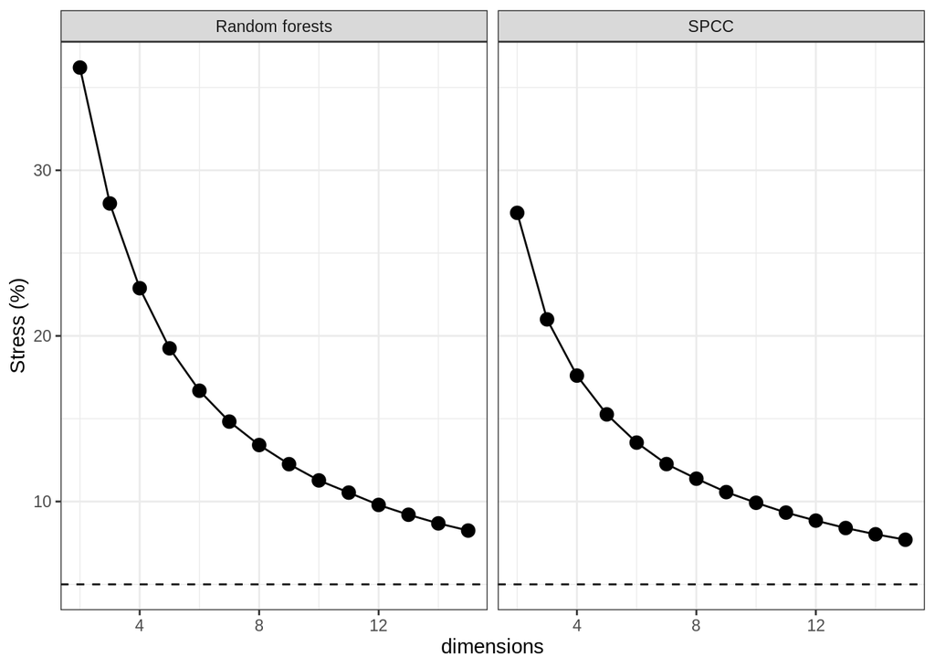

```r
# x11()

stress_df %>%
  ggplot(aes(x = dimensions, y = stress)) +
  geom_point(size = 3) +
  geom_line() +
  facet_wrap(~ sim_meth) +
  ylab("Stress (%)") +
  geom_hline(aes(yintercept = 5), linetype = "dashed") +
  theme_bw()
```

```r
stress_df %>%
  group_by(sim_meth) %>%
  dplyr::summarise(
    min_stress = min(stress)
  )
```

```
## # A tibble: 2 × 2
##   sim_meth       min_stress
##   <chr>               <dbl>
## 1 Random forests       8.25
## 2 SPCC                 7.69
```

## Extract optimized MDS dimensions

The dotted line at 5% is a general rule of thumb for low stress. I couldn’t run MDS with more than 15 dimensions for the site scale on my local machine, but this maximum dimensions I could run for the site scale yielded low stress as well, around 7 - 8%.

Extract the MDS solution with 15 dimensions per similarity method and social scale. Write out a single data frame across social scales and similarity methods.

```r
# Get the MDS solution with the 15 dimensions per similarity method (these had the lowest stress values)
opt_spcc <- iso_spcc$`15`$points
str(opt_spcc)

opt_rf <- iso_rf$`15`$points
str(opt_rf)

# Make a data frame of the first two MDS dimensions and call metadata
mds_df <- data.frame(sound.files = c(dimnames(opt_spcc)[[1]], dimnames(opt_rf)[[1]])) %>%
  dplyr::mutate(
    X = c(opt_spcc[, 1], opt_rf[, 1]),
    Y = c(opt_spcc[, 2], opt_rf[, 2]),
    sim_meth = c(rep("SPCC", length(opt_spcc[, 1])), rep("Random forests", length(opt_rf[, 1])))
  ) %>%
  inner_join(
   nat_int_est %>%
     as_tibble() %>%
     dplyr::select(sound.files, social_scale, range, country, region, dept_state, introduced_city, year, site, site_year, Bird_ID),
   by = c("sound.files")
  )

glimpse(mds_df)

# Checking, looks good
mds_df %>%
  dplyr::filter(sim_meth == "SPCC") %>%
  nrow() == nrow(nat_int_est)

mds_df %>%
  dplyr::filter(sim_meth == "Random forests") %>%
  nrow() == dim(vp_prox_mat)[1]

write.csv(mds_df, file.path(path, "optimized_MDS_coords_metadata.csv"), row.names = FALSE)
```

# Acoustic space figures

Use these MDS coordinates from the optimal MDS solutions per social scale and similarity method to make acoustic space plots below.

```r
mds_df <- read.csv(file.path(path, "optimized_MDS_coords_metadata.csv"))
glimpse(mds_df)
```

```
## Rows: 3,008
## Columns: 14
## $ sound.files     <chr> "2017_07_17_EMBR_INDIV-RAW_MZ000199_1.WAV", "2017_07_1…
## $ X               <dbl> -0.20546470, -0.12592469, -0.35963393, -0.37731131, -0…
## $ Y               <dbl> -0.1007781046, 0.1196440220, 0.0213235142, 0.094444145…
## $ sim_meth        <chr> "SPCC", "SPCC", "SPCC", "SPCC", "SPCC", "SPCC", "SPCC"…
## $ social_scale    <chr> "Individual", "Individual", "Individual", "Individual"…
## $ range           <chr> "Native", "Native", "Native", "Native", "Native", "Nat…
## $ country         <chr> "Uruguay", "Uruguay", "Uruguay", "Uruguay", "Uruguay",…
## $ region          <chr> "West", "West", "West", "West", "West", "West", "West"…
## $ dept_state      <chr> "Colonia", "Colonia", "Colonia", "Colonia", "Colonia",…
## $ introduced_city <chr> NA, NA, NA, NA, NA, NA, NA, NA, NA, NA, NA, NA, NA, NA…
## $ year            <int> 2017, 2017, 2017, 2017, 2017, 2017, 2017, 2017, 2017, …
## $ site            <chr> "EMBR", "EMBR", "EMBR", "EMBR", "EMBR", "EMBR", "EMBR"…
## $ site_year       <chr> "EMBR_2017", "EMBR_2017", "EMBR_2017", "EMBR_2017", "E…
## $ Bird_ID         <chr> "NAT-RAW", "NAT-RAW", "NAT-RAW", "NAT-RAW", "NAT-ZW8",…
```

```r
table(mds_df$sim_meth)
```

```
##
## Random forests           SPCC
##           1426           1582
```

## Figure 2: Individual scale, random forests

A visual of random forests acoustic space at the individual scale per range, using the random forests validation matrix. Note that this is the same matrix used to make the supplementary figure demonstrating random forests validation.

```r
rf_validatn <- read.csv(file.path(path, "supervised_RF_datasets_acousticSimilarity.csv")) %>%
  dplyr::filter(rf_set == "validation") %>%
  dplyr::select(sound.files, range, country, region, dept_state, introduced_city, site, site_year, year, Bird_ID)

glimpse(rf_validatn)
```

```
## Rows: 73
## Columns: 10
## $ sound.files     <chr> "2017_07_17_EMBR_INDIV-RAW_MZ000199_1.WAV", "2017_07_1…
## $ range           <chr> "Native", "Native", "Native", "Native", "Native", "Nat…
## $ country         <chr> "Uruguay", "Uruguay", "Uruguay", "Uruguay", "Uruguay",…
## $ region          <chr> "West", "West", "West", "West", "West", "West", "West"…
## $ dept_state      <chr> "Colonia", "Colonia", "Colonia", "Colonia", "Colonia",…
## $ introduced_city <chr> NA, NA, NA, NA, NA, NA, NA, NA, NA, NA, NA, NA, NA, NA…
## $ site            <chr> "EMBR", "EMBR", "EMBR", "EMBR", "EMBR", "EMBR", "EMBR"…
## $ site_year       <chr> "EMBR_2017", "EMBR_2017", "EMBR_2017", "EMBR_2017", "E…
## $ year            <int> 2017, 2017, 2017, 2017, 2017, 2017, 2017, 2017, 2017, …
## $ Bird_ID         <chr> "NAT-RAW", "NAT-RAW", "NAT-RAW", "NAT-RAW", "NAT-ZW8",…
```

```r
# Individual ids
indivs <- rf_validatn %>%
  # Remove the ASCA individual that was a loner in El Paso, TX
  # This individual is shown in a validation figure in supplementary material
  dplyr::filter(site != "ASCA") %>%
  pull(Bird_ID) %>%
  unique() %>%
  as.character()

indivs
```

```
## [1] "NAT-RAW"  "NAT-ZW8"  "NAT-UM3"  "NAT-UM5"  "INT-UM9"  "INT-UM10" "INT-UM16"
## [8] "INT-UM17"
```

```r
# Encode the individual IDs as unique numbers per range to make the visual easier to interpret
id_df <- data.frame(indiv_ids = indivs) %>%
  dplyr::mutate(
    num_ids = c(paste("Native", seq(1, 4, 1), sep = "-"), paste("Introduced", seq(1, 4, 1), sep = "-"))
  )

id_df
```

```
##   indiv_ids      num_ids
## 1   NAT-RAW     Native-1
## 2   NAT-ZW8     Native-2
## 3   NAT-UM3     Native-3
## 4   NAT-UM5     Native-4
## 5   INT-UM9 Introduced-1
## 6  INT-UM10 Introduced-2
## 7  INT-UM16 Introduced-3
## 8  INT-UM17 Introduced-4
```

```r
#  indiv_ids    num_ids
# 1   NAT-RAW   Native-1
# 2   NAT-ZW8   Native-2
# 3   NAT-UM3   Native-3
# 4   NAT-UM5   Native-4
# 5   INT-UM9 Introduced-1
# 6  INT-UM10 Introduced-2
# 7  INT-UM16 Introduced-3
# 8  INT-UM17 Introduced-4

# Subset the MDS coordinates by calls for these individuals and join with the new ids
tmp_mds_df <- mds_df %>%
  dplyr::filter(social_scale == "Individual") %>%
  dplyr::filter(sim_meth == "Random forests") %>%
  dplyr::rename(`ids` = "Bird_ID") %>%
  dplyr::filter(ids %in% indivs) %>%
  dplyr::mutate(
    sim_meth = gsub("Random forests", "Random forests validation", sim_meth),
    range = factor(range, levels = c("Native", "Introduced"))
  ) %>%
  inner_join(
    id_df,
    by = c("ids" = "indiv_ids")
  ) %>%
  dplyr::mutate(
    num_ids = factor(num_ids, levels = c(paste("Native", seq(1, 4, 1), sep = "-"), paste("Introduced", seq(1, 4, 1), sep = "-")))
  )

glimpse(tmp_mds_df)
```

```
## Rows: 48
## Columns: 15
## $ sound.files     <chr> "2017_07_17_EMBR_INDIV-RAW_MZ000199_1.WAV", "2017_07_1…
## $ X               <dbl> -0.086268888, -0.107501930, -0.115832457, -0.118272701…
## $ Y               <dbl> -0.003607321, 0.003833810, 0.020444967, 0.031731483, -…
## $ sim_meth        <chr> "Random forests validation", "Random forests validatio…
## $ social_scale    <chr> "Individual", "Individual", "Individual", "Individual"…
## $ range           <fct> Native, Native, Native, Native, Native, Native, Native…
## $ country         <chr> "Uruguay", "Uruguay", "Uruguay", "Uruguay", "Uruguay",…
## $ region          <chr> "West", "West", "West", "West", "West", "West", "West"…
## $ dept_state      <chr> "Colonia", "Colonia", "Colonia", "Colonia", "Colonia",…
## $ introduced_city <chr> NA, NA, NA, NA, NA, NA, NA, NA, NA, NA, NA, NA, NA, NA…
## $ year            <int> 2017, 2017, 2017, 2017, 2017, 2017, 2017, 2017, 2017, …
## $ site            <chr> "EMBR", "EMBR", "EMBR", "EMBR", "EMBR", "EMBR", "EMBR"…
## $ site_year       <chr> "EMBR_2017", "EMBR_2017", "EMBR_2017", "EMBR_2017", "E…
## $ ids             <chr> "NAT-RAW", "NAT-RAW", "NAT-RAW", "NAT-RAW", "NAT-ZW8",…
## $ num_ids         <fct> Native-1, Native-1, Native-1, Native-1, Native-2, Nati…
```

```r
unique(tmp_mds_df$num_ids)
```

```
## [1] Native-1     Native-2     Native-3     Native-4     Introduced-1
## [6] Introduced-2 Introduced-3 Introduced-4
## 8 Levels: Native-1 Native-2 Native-3 Native-4 Introduced-1 ... Introduced-4
```

```r
levels(tmp_mds_df$num_ids)
```

```
## [1] "Native-1"     "Native-2"     "Native-3"     "Native-4"     "Introduced-1"
## [6] "Introduced-2" "Introduced-3" "Introduced-4"
```

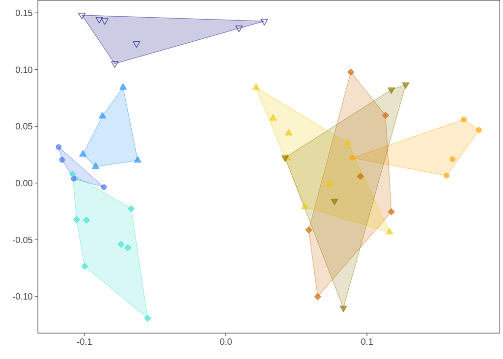

```r
# Colors by range, hues by individual
cols <- c(
  # Native range
  scales::alpha(c("royalblue2", "turquoise", "dodgerblue", "navy"), 0.65),
  # Introduced range
  scales::alpha(c("orange", "darkorange3", "gold2", "gold4"), 0.65))

# Shapes by individual or site
shps <- c(
  # Native range
  c(21, 23, 24, 6),
  # Introduced range
  c(21, 23, 24, 25)
)

# Convex hull polygons per indiviual
hulls <- plyr::ddply(tmp_mds_df, "num_ids", function(x){
  x[chull(x$X, x$Y), ]
})

gg <- tmp_mds_df %>%
  ggplot(aes(x = X, y = Y, shape = num_ids)) +
  geom_polygon(data = hulls, aes(x = X, y = Y, fill = num_ids, color = num_ids), alpha = 0.2, size = 0.2, show.legend = FALSE) +
  geom_point(aes(fill = num_ids, color = num_ids), size = 2, stroke = 0.5) +
  scale_shape_manual(values = shps) +
  scale_color_manual(values = cols) +
  scale_fill_manual(values = cols) +
  xlab("") + ylab("") +
  guides(color = "none", shape = "none", fill = "none") +
  theme_bw() +
  theme(
    axis.title = element_text(size = 14),
    axis.text = element_text(size = 9),
    strip.text.x = element_text(size = 12),
    strip.text.y = element_text(size = 10),
    panel.grid.major = element_blank(),
    panel.grid.minor = element_blank(),
    axis.ticks = element_line(size = 0.25),
    plot.margin = margin(0, 3, -3, -3)
  )
gg
```

```r
# ggsave(file.path(gpath, "HierarchicalMapping_RFAcousticSpace_IndivScale.tiff"), units = "in", width = 4, height = 4.25, dpi = 300)

# dev.off()

# Save the legend separately
# gg_leg <- gtable::gtable_filter(ggplot_gtable(ggplot_build(
#   gg +
#     guides(color = guide_legend(title = "Individuals", title.position = "top", nrow = 2, byrow = TRUE), shape = guide_legend(title = "Individuals", title.position = "top", nrow = 2, byrow = TRUE), fill = guide_legend(title = "Individuals", title.position = "top", nrow = 2, byrow = TRUE)) +
#     theme(
#       legend.title = element_text(size = 10),
#       legend.text = element_text(size = 10),
#       legend.justification = "center",
#       legend.position = "top",
#       legend.margin = margin(0, 0, 0, 0),
#       legend.box.margin = margin(3, -5, -7, -5), # top, right, bottom, left
#       legend.key.width = unit(0.5, "lines"),
#       legend.key.height = unit(0.5, "lines")
#     )
# )), "guide-box")

# dev.off()

# tiff(file.path(gpath, "HierarchicalMapping_RFAcousticSpace_IndivScale_Legend.tiff"), units = "in", width = 5, height = 2, res = 300)
# grid.draw(gg_leg)
# dev.off()
```

## Figure 3: Site scale, random forests

Make a plot of random forests acoustic space at the site scale between ranges.

```r
############### Site scale calls, full dataset #############

# Native range: Randomly sample 4 sites from the Colonia department with more than 10 calls
set.seed(seed)
nat_sites <- nat_int_est %>%
  dplyr::filter(range == "Native" & dept_state == "Colonia" & social_scale == "Site") %>%
  group_by(site_year) %>%
  dplyr::summarise(
    n_calls = n()
  ) %>%
  dplyr::filter(n_calls > 10) %>%
  pull(site_year) %>%
  unique() %>%
  sample(4, replace = FALSE)

nat_sites
```

[output not shown]

```r
# Introduced range: Get the 4 of the 6 sites from Austin 2019 with more than 10 calls
int_sites <- nat_int_est %>%
  dplyr::filter(range == "Introduced" & year == "2019" & social_scale == "Site" & introduced_city == "Austin") %>%
  group_by(site_year) %>%
  dplyr::summarise(
    n_calls = n()
  ) %>%
  dplyr::filter(n_calls > 10) %>%
  pull(site_year) %>%
  unique()

int_sites
```

```
## [1] "ELEM_2019" "INTR_2019" "MART_2019" "SOCC_2019"
```

```r
# Encode the site IDs as unique numbers per range to make the visual easier to interpret
id_df <- data.frame(site_ids = c(nat_sites, int_sites)) %>%
  dplyr::mutate(
    num_ids = c(paste("Native", seq(1, 4, 1), sep = "-"), paste("Introduced", seq(1, 4, 1), sep = "-"))
  )

id_df
```

```
##       site_ids      num_ids
## 1 INES-08_2017     Native-1
## 2    PIED_2017     Native-2
## 3    ROSA_2017     Native-3
## 4    LENA_2017     Native-4
## 5    ELEM_2019 Introduced-1
## 6    INTR_2019 Introduced-2
## 7    MART_2019 Introduced-3
## 8    SOCC_2019 Introduced-4
```

```r
#       site_ids      num_ids
# 1 INES-08_2017     Native-1
# 2    PIED_2017     Native-2
# 3    ROSA_2017     Native-3
# 4    LENA_2017     Native-4
# 5    ELEM_2019 Introduced-1
# 6    INTR_2019 Introduced-2
# 7    MART_2019 Introduced-3
# 8    SOCC_2019 Introduced-4

# Subset the MDS coordinates by calls for these sites
tmp_mds_df <- mds_df %>%
  dplyr::filter(social_scale == "Site") %>%
  dplyr::filter(sim_meth == "Random forests") %>%
  dplyr::filter(site_year %in% c(nat_sites, int_sites)) %>%
  # After filtering, make the id column sites so that the legend is less busy
  dplyr::rename(`ids` = "site_year") %>%
  inner_join(
    id_df,
    by = c("ids" = "site_ids")
  ) %>%
  dplyr::mutate(
    num_ids = factor(num_ids, levels = c(paste("Native", seq(1, 4, 1), sep = "-"), paste("Introduced", seq(1, 4, 1), sep = "-")))
  )

glimpse(tmp_mds_df)
```

```
## Rows: 363
## Columns: 15
## $ sound.files     <chr> "2017_07_13_INES-08_1093_1.WAV", "2017_07_13_INES-08_1…
## $ X               <dbl> 0.027272268, -0.015263035, -0.020093884, 0.029441657, …
## $ Y               <dbl> 0.229549093, 0.118569847, 0.065583417, 0.031116725, 0.…
## $ sim_meth        <chr> "Random forests", "Random forests", "Random forests", …
## $ social_scale    <chr> "Site", "Site", "Site", "Site", "Site", "Site", "Site"…
## $ range           <chr> "Native", "Native", "Native", "Native", "Native", "Nat…
## $ country         <chr> "Uruguay", "Uruguay", "Uruguay", "Uruguay", "Uruguay",…
## $ region          <chr> "West", "West", "West", "West", "West", "West", "West"…
## $ dept_state      <chr> "Colonia", "Colonia", "Colonia", "Colonia", "Colonia",…
## $ introduced_city <chr> NA, NA, NA, NA, NA, NA, NA, NA, NA, NA, NA, NA, NA, NA…
## $ year            <int> 2017, 2017, 2017, 2017, 2017, 2017, 2017, 2017, 2017, …
## $ site            <chr> "INES-08", "INES-08", "INES-08", "INES-08", "INES-08",…
## $ ids             <chr> "INES-08_2017", "INES-08_2017", "INES-08_2017", "INES-…
## $ Bird_ID         <chr> NA, NA, NA, NA, NA, NA, NA, NA, NA, NA, NA, NA, NA, NA…
## $ num_ids         <fct> Native-1, Native-1, Native-1, Native-1, Native-1, Nati…
```

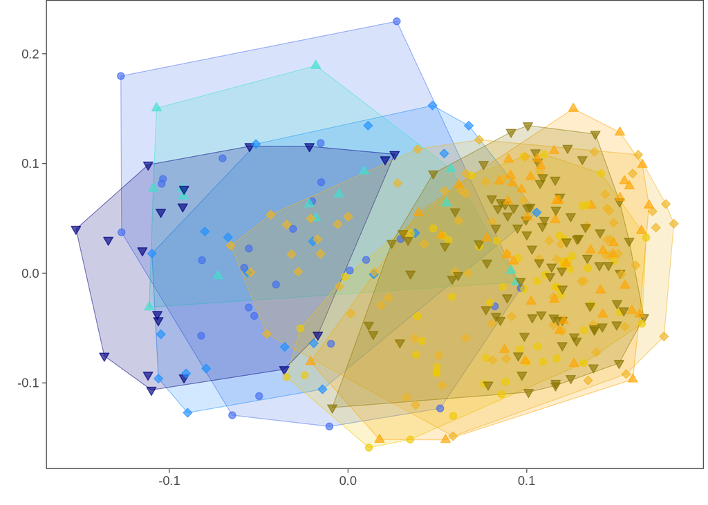

```r
# View(tmp_mds_df)

# Colors by range, hues by site
cols <- c(
  # Native range
  scales::alpha(c("royalblue2", "dodgerblue", "turquoise", "navy"), 0.65),
  # Introduced range
  scales::alpha(c("gold2", "goldenrod2", "orange",  "gold4"), 0.65)
)

# Shapes by site
shps <- c(
  # Native range
  c(21, 23, 24, 25),
  # Introduced range
  c(21, 23, 24, 25)
)

# Convex hull polygons per site
hulls <- plyr::ddply(tmp_mds_df, "num_ids", function(x){
  x[chull(x$X, x$Y), ]
})

gg <- tmp_mds_df %>%
  ggplot(aes(x = X, y = Y, shape = num_ids)) +
  geom_polygon(data = hulls, aes(x = X, y = Y, fill = num_ids, color = num_ids), alpha = 0.2, size = 0.2, show.legend = FALSE) +
  geom_point(aes(fill = num_ids, color = num_ids), size = 2, stroke = 0.5) +
  scale_shape_manual(values = shps) +
  scale_color_manual(values = cols) +
  scale_fill_manual(values = cols) +
  xlab("") + ylab("") +
  guides(color = "none", shape = "none", fill = "none") +
  theme_bw() +
  theme(
    axis.title = element_text(size = 14),
    axis.text = element_text(size = 9),
    strip.text.x = element_text(size = 12),
    strip.text.y = element_text(size = 10),
    panel.grid.major = element_blank(),
    panel.grid.minor = element_blank(),
    axis.ticks = element_line(size = 0.25),
    plot.margin = margin(0, 3, -3, -3)
  )

gg
```

```r
# ggsave(file.path(gpath, "HierarchicalMapping_RFAcousticSpace_SiteScale.tiff"), units = "in", width = 4, height = 4.25, dpi = 300)
#
# dev.off()
#
# # Save the legend separately
# gg_leg <- gtable::gtable_filter(ggplot_gtable(ggplot_build(
#   gg +
#     guides(color = guide_legend(title = "Sites", title.position = "top", nrow = 2, byrow = TRUE), shape = guide_legend(title = "Sites", title.position = "top", nrow = 2, byrow = TRUE), fill = guide_legend(title = "Sites", title.position = "top", nrow = 2, byrow = TRUE)) +
#     theme(
#       legend.title = element_text(size = 10),
#       legend.text = element_text(size = 10),
#       legend.justification = "center",
#       legend.position = "top",
#       legend.margin = margin(0, 0, 0, 0),
#       legend.box.margin = margin(3, -5, -7, -5), # top, right, bottom, left
#       legend.key.width = unit(0.5, "lines"),
#       legend.key.height = unit(0.5, "lines")
#     )
# )), "guide-box")
#
# dev.off()
#
# tiff(file.path(gpath, "HierarchicalMapping_RFAcousticSpace_SiteScale_Legend.tiff"), units = "in", width = 5, height = 2, res = 300)
# grid.draw(gg_leg)
# dev.off()
```

# Supplementary acoustic space figures

## Individual scale, SPCC acoustic space

Make a figure with panels by individuals use for training and validating the final random forests model.

```r
sup_rf_df <- read.csv(file.path(path, "supervised_RF_datasets_acousticSimilarity.csv")) %>%
  dplyr::select(sound.files, range, country, region, dept_state, introduced_city, site, site_year, year, Bird_ID, rf_set)

glimpse(sup_rf_df)
```

```
## Rows: 1,596
## Columns: 11
## $ sound.files     <chr> "2017_07_17_EMBR_INDIV-RAW_MZ000199_1.WAV", "2017_07_1…
## $ range           <chr> "Native", "Native", "Native", "Native", "Native", "Nat…
## $ country         <chr> "Uruguay", "Uruguay", "Uruguay", "Uruguay", "Uruguay",…
## $ region          <chr> "West", "West", "West", "West", "West", "West", "West"…
## $ dept_state      <chr> "Colonia", "Colonia", "Colonia", "Colonia", "Colonia",…
## $ introduced_city <chr> NA, NA, NA, NA, NA, NA, NA, NA, NA, NA, NA, NA, NA, NA…
## $ site            <chr> "EMBR", "EMBR", "EMBR", "EMBR", "EMBR", "EMBR", "EMBR"…
## $ site_year       <chr> "EMBR_2017", "EMBR_2017", "EMBR_2017", "EMBR_2017", "E…
## $ year            <int> 2017, 2017, 2017, 2017, 2017, 2017, 2017, 2017, 2017, …
## $ Bird_ID         <chr> "NAT-RAW", "NAT-RAW", "NAT-RAW", "NAT-RAW", "NAT-ZW8",…
## $ rf_set          <chr> "validation", "validation", "validation", "validation"…
```

```r
# Get individuals used for random forests training
t_indivs <- sup_rf_df %>%
  dplyr::filter(rf_set == "training") %>%
  pull(Bird_ID) %>%
  unique() %>%
  as.character()

t_indivs
```

```
## [1] "NAT-UM2"  "NAT-UM4"  "NAT-UM1"  "NAT-AAT"  "INT-UM1"  "INT-UM5"  "INT-UM7"
## [8] "INT-UM19"
```

```r
# Get individuals used for random forests validation
v_indivs <- sup_rf_df %>%
  dplyr::filter(rf_set == "validation") %>%
  # Remove the ASCA individual that was a loner in El Paso, TX
  # This individual is shown in a validation figure in supplementary material
  # dplyr::filter(site != "ASCA") %>%
  pull(Bird_ID) %>%
  unique() %>%
  as.character()

v_indivs
```

```
## [1] "NAT-RAW"  "NAT-ZW8"  "NAT-UM3"  "NAT-UM5"  "INT-UM6"  "INT-UM9"  "INT-UM10"
## [8] "INT-UM16" "INT-UM17"
```

```r
# Subset the MDS coordinates by calls for these individuals
tmp_mds_df <- mds_df %>%
  dplyr::filter(social_scale == "Individual") %>%
  dplyr::filter(sim_meth == "SPCC") %>%
  dplyr::rename(`ids` = "Bird_ID") %>%
  dplyr::filter(ids %in% c(t_indivs, v_indivs)) %>%
  dplyr::mutate(
    ids = as.character(ids),
    # ids = gsub("^NAT-|^INT-", "", ids),
    ids = factor(ids, levels = c(t_indivs, v_indivs))
  ) %>%
  # Add a column for random forests dataset to split the plot below into panels
  inner_join(
    sup_rf_df %>%
      dplyr::select(sound.files, rf_set),
    by = "sound.files"
  ) %>%
  dplyr::mutate(
    rf_set = ifelse(rf_set == "training", "8 individuals used for\n random forests training", "9 individuals used for\n random forests validation"),
    rf_set = factor(rf_set, levels = c("8 individuals used for\n random forests training", "9 individuals used for\n random forests validation")),
    range = factor(range, levels = c("Native", "Introduced"))
  )

glimpse(tmp_mds_df)
```

```
## Rows: 229
## Columns: 15
## $ sound.files     <chr> "2017_07_17_EMBR_INDIV-RAW_MZ000199_1.WAV", "2017_07_1…
## $ X               <dbl> -0.20546470, -0.12592469, -0.35963393, -0.37731131, -0…
## $ Y               <dbl> -0.1007781046, 0.1196440220, 0.0213235142, 0.094444145…
## $ sim_meth        <chr> "SPCC", "SPCC", "SPCC", "SPCC", "SPCC", "SPCC", "SPCC"…
## $ social_scale    <chr> "Individual", "Individual", "Individual", "Individual"…
## $ range           <fct> Native, Native, Native, Native, Native, Native, Native…
## $ country         <chr> "Uruguay", "Uruguay", "Uruguay", "Uruguay", "Uruguay",…
## $ region          <chr> "West", "West", "West", "West", "West", "West", "West"…
## $ dept_state      <chr> "Colonia", "Colonia", "Colonia", "Colonia", "Colonia",…
## $ introduced_city <chr> NA, NA, NA, NA, NA, NA, NA, NA, NA, NA, NA, NA, NA, NA…
## $ year            <int> 2017, 2017, 2017, 2017, 2017, 2017, 2017, 2017, 2017, …
## $ site            <chr> "EMBR", "EMBR", "EMBR", "EMBR", "EMBR", "EMBR", "EMBR"…
## $ site_year       <chr> "EMBR_2017", "EMBR_2017", "EMBR_2017", "EMBR_2017", "E…
## $ ids             <fct> NAT-RAW, NAT-RAW, NAT-RAW, NAT-RAW, NAT-ZW8, NAT-ZW8, …
## $ rf_set          <fct> 9 individuals used for
##  random forests validation, 9 in…
```

```r
unique(tmp_mds_df$ids)
```

```
##  [1] NAT-RAW  NAT-ZW8  NAT-UM2  NAT-UM3  NAT-UM4  NAT-UM1  NAT-AAT  NAT-UM5
##  [9] INT-UM1  INT-UM5  INT-UM6  INT-UM7  INT-UM9  INT-UM10 INT-UM16 INT-UM17
## [17] INT-UM19
## 17 Levels: NAT-UM2 NAT-UM4 NAT-UM1 NAT-AAT INT-UM1 INT-UM5 INT-UM7 ... INT-UM17
```

```r
levels(tmp_mds_df$ids)
```

```
##  [1] "NAT-UM2"  "NAT-UM4"  "NAT-UM1"  "NAT-AAT"  "INT-UM1"  "INT-UM5"
##  [7] "INT-UM7"  "INT-UM19" "NAT-RAW"  "NAT-ZW8"  "NAT-UM3"  "NAT-UM5"
## [13] "INT-UM6"  "INT-UM9"  "INT-UM10" "INT-UM16" "INT-UM17"
```

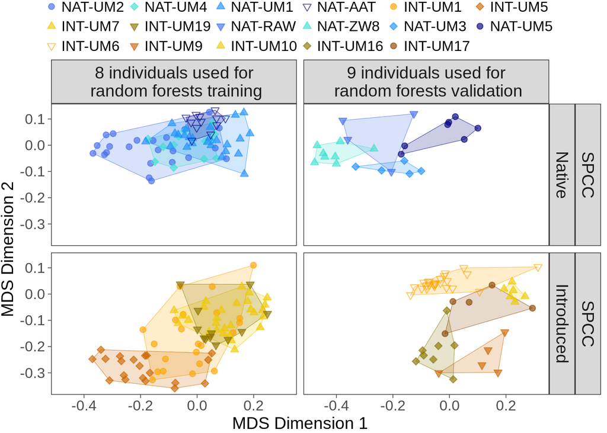

```r
# Colors by range, hues by individual, then repeated across random forests datasets
cols <- c(
  # Native range, training
  scales::alpha(c("royalblue2", "turquoise", "dodgerblue", "navy"), 0.65),
  # Introduced range, training
  scales::alpha(c("orange", "darkorange3", "gold2", "gold4"), 0.65),
# Native range, validation
  scales::alpha(c("royalblue2", "turquoise", "dodgerblue", "navy"), 0.65),
  # Introduced range, validation
  scales::alpha(c("orange", "darkorange3", "gold2", "gold4", "darkorange4"), 0.65)
)

# Shapes by individual or site
shps <- c(
  # Native range, training
  c(21, 23, 24, 6),
  # Introduced range, training
  c(21, 23, 24, 25),
  # Native range, validation
  rev(c(21, 23, 24, 25)),
  # Introduced range, validation
  rev(c(21, 23, 24, 25, 6))
)

# Convex hull polygons per indiviual
hulls <- plyr::ddply(tmp_mds_df, "ids", function(x){
  x[chull(x$X, x$Y), ]
})

tmp_mds_df %>%
  ggplot(aes(x = X, y = Y, shape = ids)) +
  geom_polygon(data = hulls, aes(x = X, y = Y, fill = ids, color = ids), alpha = 0.2, size = 0.2, show.legend = FALSE) +
  geom_point(aes(fill = ids, color = ids), size = 2, stroke = 0.5) +
  facet_grid(rows = vars(sim_meth, range), cols = vars(rf_set), scales = "fixed") +
  scale_shape_manual(values = shps) +
  scale_color_manual(values = cols) +
  scale_fill_manual(values = cols) +
  xlab("MDS Dimension 1") + ylab("MDS Dimension 2") +
  guides(color = guide_legend(title = "", nrow = 3, byrow = TRUE), shape = guide_legend(title = "", nrow = 3, byrow = TRUE), fill = guide_legend(title = "", nrow = 3, byrow = TRUE)) +
  theme_bw() +
  theme(
    axis.title = element_text(size = 14),
    axis.text = element_text(size = 12),
    strip.text.x = element_text(size = 14),
    strip.text.y = element_text(size = 14),
    legend.text = element_text(size = 12),
    legend.justification = "center",
    panel.grid.major = element_blank(),
    panel.grid.minor = element_blank(),
    axis.ticks = element_line(size = 0.25),
    legend.position = "top",
    legend.margin = margin(0, 0, 0, 0),
    legend.box.margin = margin(0, 5, -5, 0), # top, right, bottom, left
    legend.key.width = unit(0.25, "lines"),
    legend.key.height = unit(0.25, "lines"),
    plot.margin = margin(0, 5, 0.5, 1)
  )
```

```r
# ggsave(file.path(gpath, "HierarchicalMapping_SPCCAcousticSpace_IndivScale.tiff"), units = "in", width = 7.48, height = 6, dpi = 300)
```

## Site scale, datasets for repeated individual sampling

Make a multi-faceted plot for random forests and SPCC similarity at the site scale per range and across site-scale datasets. Filter the MDS coordinates by calls retained in the clustering and visual classification filtered datasets. Use the same site-years initialized above for Figure 3.

```r
nat_sites
```

```
## [1] "INES-08_2017" "PIED_2017"    "ROSA_2017"    "LENA_2017"
```

```r
int_sites
```

```
## [1] "ELEM_2019" "INTR_2019" "MART_2019" "SOCC_2019"
```

```r
# Full dataset for these sites
nf_calls <- site_scale_nf %>%
  dplyr::filter(social_scale == "Site") %>%
  dplyr::filter(site_year %in% c(nat_sites, int_sites)) %>%
  pull(sound.files)

# Clustering dataset for these sites
cf_calls <- site_scale_cf %>%
  dplyr::filter(social_scale == "Site") %>%
  dplyr::filter(site_year %in% c(nat_sites, int_sites)) %>%
  pull(sound.files)

# Visual classification dataset for these sites
vf_calls <- site_scale_vf %>%
  dplyr::filter(social_scale == "Site") %>%
  dplyr::filter(site_year %in% c(nat_sites, int_sites)) %>%
  pull(sound.files)

# Iterate over similarity methods and datasets to perform MDS
# Combine MDS results to make a faceted graphic per similarity method
sim_meth <- c("SPCC", "Random forests")
datasets <- c("Full", "Clustering", "Visual classification")
call_list <- list(nf_calls, cf_calls, vf_calls)

# Iterate over similarity methods and site scale datasets, make a data frame with MDS coordinates for native and introduced range calls per similarity methodand dataset and similarity method
# s <- 1
# d <- 2
site_datasets_mds_df <- rbindlist(pblapply(1:length(sim_meth), function(s){

  sub_df <- rbindlist(pblapply(1:length(datasets), function(d){

    meth <- sim_meth[s]

    # Filter the MDS data frame by the similarity method and the calls in the given site scale dataset
    tmp_df <- mds_df %>%
      dplyr::filter(sim_meth == meth) %>%
      dplyr::filter(sound.files %in% call_list[[d]]) %>%
      droplevels() %>%
      dplyr::mutate(
        dataset = datasets[d]
      )

    return(tmp_df)

  }))

  return(sub_df)

}))

glimpse(site_datasets_mds_df)
```

```
## Rows: 1,152
## Columns: 15
## $ sound.files     <chr> "2017_07_13_INES-08_1093_1.WAV", "2017_07_13_INES-08_1…
## $ X               <dbl> 0.08864386, -0.04356221, 0.08423088, 0.05888239, -0.08…
## $ Y               <dbl> 0.1218763208, 0.0290399679, 0.1487599727, 0.1554988504…
## $ sim_meth        <chr> "SPCC", "SPCC", "SPCC", "SPCC", "SPCC", "SPCC", "SPCC"…
## $ social_scale    <chr> "Site", "Site", "Site", "Site", "Site", "Site", "Site"…
## $ range           <chr> "Native", "Native", "Native", "Native", "Native", "Nat…
## $ country         <chr> "Uruguay", "Uruguay", "Uruguay", "Uruguay", "Uruguay",…
## $ region          <chr> "West", "West", "West", "West", "West", "West", "West"…
## $ dept_state      <chr> "Colonia", "Colonia", "Colonia", "Colonia", "Colonia",…
## $ introduced_city <chr> NA, NA, NA, NA, NA, NA, NA, NA, NA, NA, NA, NA, NA, NA…
## $ year            <int> 2017, 2017, 2017, 2017, 2017, 2017, 2017, 2017, 2017, …
## $ site            <chr> "INES-08", "INES-08", "INES-08", "INES-08", "INES-08",…
## $ site_year       <chr> "INES-08_2017", "INES-08_2017", "INES-08_2017", "INES-…
## $ Bird_ID         <chr> NA, NA, NA, NA, NA, NA, NA, NA, NA, NA, NA, NA, NA, NA…
## $ dataset         <chr> "Full", "Full", "Full", "Full", "Full", "Full", "Full"…
```

```r
site_datasets_mds_df %>%
  group_by(sim_meth, dataset, range) %>%
  dplyr::summarise(n_calls = n())
```

```
## # A tibble: 12 × 4
## # Groups:   sim_meth, dataset [6]
##    sim_meth       dataset               range      n_calls
##    <chr>          <chr>                 <chr>        <int>
##  1 Random forests Clustering            Introduced      44
##  2 Random forests Clustering            Native          44
##  3 Random forests Full                  Introduced     281
##  4 Random forests Full                  Native          82
##  5 Random forests Visual classification Introduced      72
##  6 Random forests Visual classification Native          53
##  7 SPCC           Clustering            Introduced      44
##  8 SPCC           Clustering            Native          44
##  9 SPCC           Full                  Introduced     281
## 10 SPCC           Full                  Native          82
## 11 SPCC           Visual classification Introduced      72
## 12 SPCC           Visual classification Native          53
```

```r
tmp_mds_df <- site_datasets_mds_df %>%
  dplyr::mutate(
    range = as.character(range),
    range = factor(range, levels = c("Native", "Introduced")),
    dataset = gsub("Visual classification", "Visual\n classification", dataset),
    dataset = factor(dataset, levels = c("Full", "Clustering", "Visual\n classification")),
    # Order sites by range
    site = factor(site, levels = gsub("_2017|_2019", "", c(nat_sites, int_sites))),
    # Make an id-dataset column for polygons below
    ids_dataset_sim = paste(site, dataset, sim_meth, sep = "-")
  )

glimpse(tmp_mds_df)
```

```
## Rows: 1,152
## Columns: 16
## $ sound.files     <chr> "2017_07_13_INES-08_1093_1.WAV", "2017_07_13_INES-08_1…
## $ X               <dbl> 0.08864386, -0.04356221, 0.08423088, 0.05888239, -0.08…
## $ Y               <dbl> 0.1218763208, 0.0290399679, 0.1487599727, 0.1554988504…
## $ sim_meth        <chr> "SPCC", "SPCC", "SPCC", "SPCC", "SPCC", "SPCC", "SPCC"…
## $ social_scale    <chr> "Site", "Site", "Site", "Site", "Site", "Site", "Site"…
## $ range           <fct> Native, Native, Native, Native, Native, Native, Native…
## $ country         <chr> "Uruguay", "Uruguay", "Uruguay", "Uruguay", "Uruguay",…
## $ region          <chr> "West", "West", "West", "West", "West", "West", "West"…
## $ dept_state      <chr> "Colonia", "Colonia", "Colonia", "Colonia", "Colonia",…
## $ introduced_city <chr> NA, NA, NA, NA, NA, NA, NA, NA, NA, NA, NA, NA, NA, NA…
## $ year            <int> 2017, 2017, 2017, 2017, 2017, 2017, 2017, 2017, 2017, …
## $ site            <fct> INES-08, INES-08, INES-08, INES-08, INES-08, INES-08, …
## $ site_year       <chr> "INES-08_2017", "INES-08_2017", "INES-08_2017", "INES-…
## $ Bird_ID         <chr> NA, NA, NA, NA, NA, NA, NA, NA, NA, NA, NA, NA, NA, NA…
## $ dataset         <fct> Full, Full, Full, Full, Full, Full, Full, Full, Full, …
## $ ids_dataset_sim <chr> "INES-08-Full-SPCC", "INES-08-Full-SPCC", "INES-08-Ful…
```

```r
levels(tmp_mds_df$site)
```

```
## [1] "INES-08" "PIED"    "ROSA"    "LENA"    "ELEM"    "INTR"    "MART"
## [8] "SOCC"
```

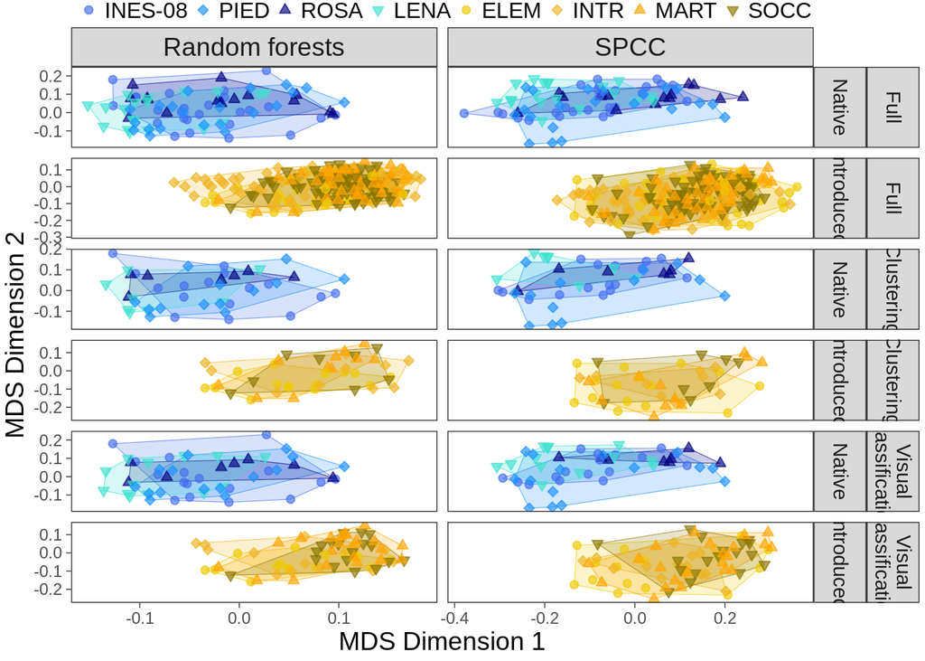

```r
# Colors by range, hues by site per range
cols <- scales::alpha(c("royalblue2", "dodgerblue", "navy", "turquoise", "gold2", "goldenrod2", "orange",  "gold4"), 0.65)

# Shapes by individual or site
shps <- rep(c(21, 23, 24, 25), 2)

# Convex hull polygons per indiviual or site
hulls <- plyr::ddply(tmp_mds_df, "ids_dataset_sim", function(x){
  x[chull(x$X, x$Y), ]
})

tmp_mds_df %>%
  ggplot(aes(x = X, y = Y, shape = site)) +
  geom_polygon(data = hulls, aes(x = X, y = Y, fill = site, color = site), alpha = 0.2, size = 0.2, show.legend = FALSE) +
  geom_point(aes(fill = site, color = site), size = 1.75, stroke = 0.5) +
  facet_grid(rows = vars(dataset, range), cols = vars(sim_meth), scales = "free") +
  scale_shape_manual(values = shps) +
  scale_color_manual(values = cols) +
  scale_fill_manual(values = cols) +
  xlab("MDS Dimension 1") + ylab("MDS Dimension 2") +
  guides(color = guide_legend(title = "", nrow = 1, byrow = TRUE), shape = guide_legend(title = "", nrow = 1, byrow = TRUE), fill = guide_legend(title = "", nrow = 1, byrow = TRUE)) +
  theme_bw() +
  theme(
    axis.title = element_text(size = 14),
    axis.text = element_text(size = 9),
    strip.text.x = element_text(size = 14),
    strip.text.y = element_text(size = 11, margin = ggplot2::margin(0.5, 0.25, 0.5, 0.25, "lines")),
    legend.title = element_text(size = 12),
    legend.text = element_text(size = 12),
    legend.justification = "center",
    legend.direction = "horizontal",
    panel.grid.major = element_blank(),
    panel.grid.minor = element_blank(),
    axis.ticks = element_line(size = 0.25),
    legend.position = "top",
    legend.margin = margin(0, 0, 0, 0),
    legend.box.margin = margin(0, -10, -7, -10), # top, right, bottom, left
    legend.key.width = unit(0.25, "lines"),
    legend.key.height = unit(0.25, "lines"),
    plot.margin = margin(0, 3, 3, 3)
  )
```

```r
# Change resolution later as needed
# ggsave(file.path(gpath, "HierarchicalMapping_RFSPCC_AcousticSpace_SiteDatasets.tiff"), units = "in", width = 7.5, height = 7, dpi = 300)
```

# References

```
1. Smith-Vidaurre, G., Araya-Salas, M., and T.F. Wright. 2020. Individual signatures outweigh social group identity in contact calls of a communally nesting parrot. Behavioral Ecology 31(2), 448-458. https://doi.org/10.1093/beheco/arz202

2. Smith-Vidaurre, G., Perez-Marrufo, V., & Wright, T. F. 2021. Individual vocal signatures show reduced complexity following invasion. Animal Behavior, 179, 15–39. https://doi.org/10.1016/j.anbehav.2021.06.020
```